# 第12回 論文のコードを読む

固有銀河の論文を、著者のコードで確かめる

# 導入

## 前回は、KMeansの中身を見た

① 場面●○○○○○

- 前回は、k-meansを自分で書いた
- `KMeans`の中で、割り当てと更新がくり返されていることを確かめた
- 中身を知っている道具なら、ほかの人のコードに出てきても読める

## 今日は、研究者のコードを読む

① 場面●●○○○○

- 研究者が論文といっしょに公開したコードを読む
- 題材は、ハッブル宇宙望遠鏡が撮った銀河の画像
- 主成分分析とクラスタリングが、どう使われているか

## 場面：天文学の研究室

① 場面●●●○○○

- あなたは、天文学の研究室に入ったばかりの新人
- 先輩から、銀河の形を調べた論文を1本渡された
- 「この論文のコードを動かして、主張が本当か確かめておいて」

## 説明は、ほとんどない

① 場面●●●●○○

- コードは著者が書いたもので、説明はほとんどない
- どこから読み、どこを動かせば、主張を確かめられるか

## 論文の主張

① 場面●●●●●○

- Uzeirbegovic, Geach, Kaviraj（2020）MNRAS 498(3): 4021–4032
- 「銀河の形は、12個ほどの固有銀河の足し算で表せる」
- 固有銀河は、銀河の画像の主成分。第9回の固有顔の、銀河版

## 決めたいこと

① 場面●●●●●●

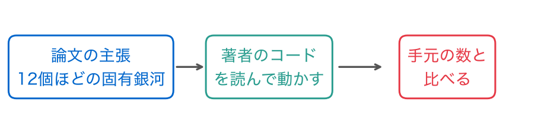

- 論文の主張を、著者のコードで確かめ、手元の数と比べる

## 手元のデータ

② 手元のデータ●○○○

- 著者がGitHubに公開したリポジトリ（emiruz/eigengalaxies）
- 著者のノート1本と、銀河の画像1,222個ぶんを取ってくる
- 答えの列はない

## 1個の銀河

② 手元のデータ●●○○

- 縦30×横30画素で、3つの波長の帯を持つ画像
- 数値の .npyと、カラーの縮小画像のPNGの、2つの形式
- 解析では、1個の銀河を1行にした表にする

## データをのぞく

② 手元のデータ●●●○

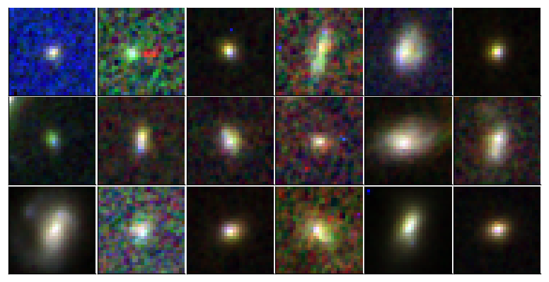

- 先頭の18個のカラー画像。丸いもの、細長いもの、明るいもの、暗いもの

## 著者のセルは、写して使う

② 手元のデータ●●●●

- 著者のノートのセルを、番号を添えてそのまま写して使う
- 「著者のセル5をそのまま写したもの」のように、どのセルかを示す
- データ（画像）は、元のリポジトリから取ってくる

## 最後に出す答え

③ 今日の問い●○

- 固有銀河いくつで、銀河の形の何%を表せるか（論文の数と比べる）
- 著者のコードを再現するときに、気をつける所

## 今日の問い

③ 今日の問い●●

論文の主張を、著者が公開したコードを読んで動かし、確かめられるか？

## もう1つのねらい：ブロックで読む

④ もう1つのねらい●○○

- 研究者のコードを、関数を作るブロックと、それを使う処理のブロックに分けて読み、動かせるようになる

## 2種類のブロック

④ もう1つのねらい●●○

- 関数を作るブロック：`def`が並ぶ。実行しても、何も起きないように見える
- 処理のブロック：作った関数を呼んで、データを変えていく

## 著者のパイプライン

④ もう1つのねらい●●●

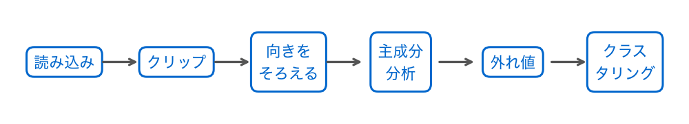

- 読み込みからクラスタリングまでの6段を、順に読んでいく

## 今日の道筋

⑤ 今日の問い●

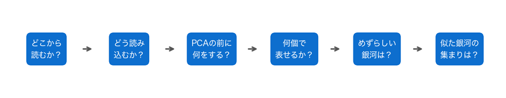

- 6つの小さな問いに答えていく

# 0. 準備

## まずは道具と、データ

- 第12回のノートを開き、上から順にセルを実行する
- 道具を呼び出し、論文のコードとデータを取ってくる

## お手本：道具を呼び出す

0節 ① 道具●

```python
import os
import json
from glob import glob
import numpy as np
import pandas as pd
import matplotlib.pyplot as plt
```

- `os`（フォルダの操作）、`json`（JSONを読む）、`glob`（ファイルを集める）

## お手本：取ってくる

0節 ② 取ってくる●○○○○

```python
WORK = '/content'   # Colab の作業場所
URL = 'https://github.com/emiruz/eigengalaxies.git'
PICK = ("'/Eigengalaxies.ipynb' '/CANDELS/GDS_[12]???.npy' "
        "'/GDS_RGBs/GDS_0[12]???.png'")      # 取ってくるファイルの型
os.chdir(WORK)
if not os.path.exists('eigengalaxies'):     # まだ取ってきていなければ
    !git clone -q --depth 1 --filter=blob:none --sparse $URL
    !cd eigengalaxies && git sparse-checkout set --no-cone {PICK}
os.chdir('eigengalaxies')                   # ここを作業の場所にする
print(sorted(os.listdir('.')))
```

## 必要なファイルだけ

0節 ② 取ってくる●●○○○

- リポジトリ全体は400MB以上ある
- `git`の機能で、必要なファイルだけを取ってくる（数秒・約40MB）
- 中身は読み飛ばしてよい。役割・入力・出力だけ読む

## !で始まる行

0節 ② 取ってくる●●●○○

- `!`で始まる行は、Pythonではなく、計算機に直接出す命令
- ここでは、`git`という道具に、リポジトリを取ってこさせている

## os.chdir：作業の場所を移す

0節 ② 取ってくる●●●●○

- `os.chdir`は、作業の場所（フォルダ）を移す関数
- 著者のコードは、このフォルダの中で動く前提で書かれている
- `'CANDELS/*.npy'`のような書き方は、作業の場所から見た位置

## 3つがそろった

0節 ② 取ってくる●●●●●

```
['CANDELS', 'Eigengalaxies.ipynb', 'GDS_RGBs']
```

- `CANDELS`（数値）、`GDS_RGBs`（カラーの縮小画像）、`Eigengalaxies.ipynb`（著者のノート）

## やってみよう：0節

0節 ③ 確かめる●

- 0節のセルを上から実行する
- 3つのファイルがそろったかを確かめる

動画の人は、ここで一時停止。

# 1. 著者のノートは、どこから読むか？

## どこから読む？

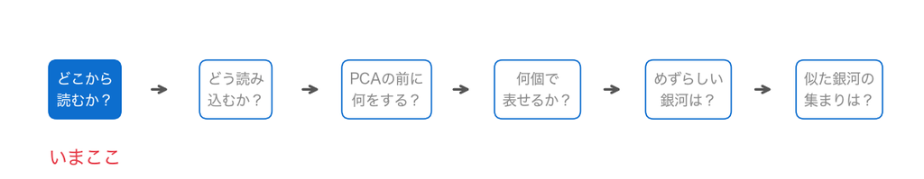

- 3つのファイルがそろった。では、著者のノートのどこから読むか

## 1行目から読まない

1節 ① 地図●

- 他人のコードは、いきなり1行目から読まない
- まず、どんなまとまり（ブロック）がどの順に並んでいるかの地図を作る
- 地図は、見出しから作れる

## ノートは、JSON

1節 ② JSON●○○○○

- ノート（`.ipynb`）は、JSONという形式の文字のファイル
- JSONは、辞書（`{名前: 値}`）とリスト（`[…]`）を入れ子にして書く形式
- `json.load`で読むと、Pythonの辞書とリストになる

## おさらい：辞書とリスト

1節 ② JSON●●○○○

```python
cell = {'cell_type': 'markdown', 'source': ['# Constants']}
print(cell['cell_type'])
print(cell['source'][0])
```

```
markdown
# Constants
```

- 辞書は`[キー]`で、リストは`[番号]`で取り出す

## お手本：JSONとして読む

1節 ② JSON●●●○○

```python
nb = json.load(open('Eigengalaxies.ipynb'))   # ノートの中身は JSON
print(list(nb.keys()))
print(len(nb['cells']), 'セル')
print(nb['cells'][2])
```

- `open`でファイルを開き、`json.load`で辞書とリストにする

## 35個のセル

1節 ② JSON●●●●○

```
['cells', 'metadata', 'nbformat', 'nbformat_minor']
35 セル
{'cell_type': 'markdown', 'metadata': {}, 'source': ['# Constants']}
```

- キー`'cells'`に、セルが35個、リストで入っている

## セルも、辞書

1節 ② JSON●●●●●

- `'cell_type'`：`'markdown'`（文章）か`'code'`（コード）
- `'source'`：中身の文字を、行ごとに分けたリスト
- セルの番号は、0から数える

## お手本：見出しだけを並べる

1節 ③ 見出し●○○○○

```python
for i, cell in enumerate(nb['cells']):
    if cell['cell_type'] == 'markdown':
        print(i, ''.join(cell['source']).strip()[:40])
```

- 文章のセルだけを取り出し、番号と先頭の40字を表示する

## 1行ずつ読む

1節 ③ 見出し●●○○○

- `enumerate`：番号と中身を組にして取り出す
- `''.join(…)`：行ごとに分かれた文字のリストを、1つの文字につなげる
- `.strip()`：前後の空白や改行を取り除く。`[:40]`で先頭の40字

## 見出しの一覧

1節 ③ 見出し●●●○○

```
0 # Common imports
2 # Constants
4 # Data Processing Functions
6 # Image Generation
8 # Data
10 # PCA
13 # Checks
15 # Outlier Detection
17 # Sample size, eigengalaxies, and explai
19 # Cumulative sum of explained variance.
21 # Reconstruction Error
23 # The Eigengalaxies
25 # Imputing Values
29 # Image Query
30 Example generator for image queries.
32 # Affinity Propagation Clustering
```

## ノートの地図

1節 ③ 見出し●●●●○

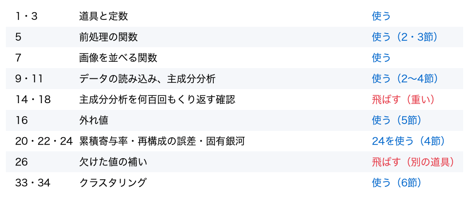

- 見出しを並べると、ノートの地図が見える

## 全部は読まない

1節 ③ 見出し●●●●●

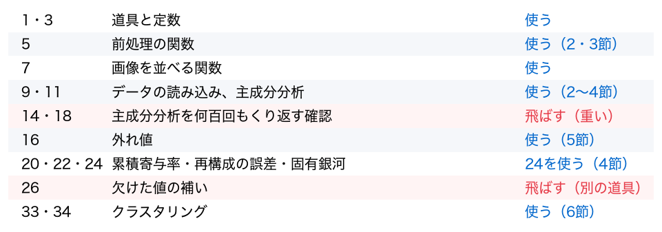

- 何百回もくり返す確認（14・18）や、別の道具が要るセル（26）は飛ばす
- 論文の主張に要るセルだけを、順に読む

## TODO①：コードのセルの1行目

1節 ④ 1行目●○○○○

```python
# TODO: コードのセルの番号と、1行目を表示する
# ヒント: if cell['cell_type'] == 'code': の中で
#         cell['source'][0] が1行目（改行は .strip() で消す）
...
```

- 1行目だけで、どのセルが何をしているかが、どこまで分かるか

## やってみよう：1節とTODO①

1節 ④ 1行目●●○○○

- 1節のお手本を上から実行する
- TODO①で、コードのセルの1行目を並べる

動画の人は、ここで一時停止。

## 答え合わせ：TODO①

1節 ④ 1行目●●●○○

```python
for i, cell in enumerate(nb['cells']):
    if cell['cell_type'] == 'code':
        print(i, cell['source'][0].strip())
```

- お手本の`'markdown'`を`'code'`にし、1行目だけを取り出す

## 19個のコードのセル

1節 ④ 1行目●●●●○

```
1 import re,os
3 SHP=(30,30,3)
5 def rescale(a):
7 import matplotlib.image as mpimg
9 raw_data,indexes=get_data()
11 pca=PCA(.96).fit(norm_data)
12 examples=[0,6,10,11,24,33,43,45,50]
14 k=12
16 lik_idx=indexes[np.argsort(lik)]
18 L=[]
20 pca_all=PCA().fit(norm_data)
22 recon_data=np.dot(scores,pca.components_)+pca.mean_
24 L=[]
26 from pyppca import ppca
27 Example generation
28 norm_samp=norm_data[inc_idx]
31 np.random.seed(1)
33 from sklearn.cluster import AffinityPropagation
34 import os
```

## 1行目で、ブロックが分かる

1節 ④ 1行目●●●●●

- `def rescale(a):`（5）は、関数を作るブロック
- `raw_data,indexes=get_data()`（9）は、処理のブロック

## お手本：道具と定数のセル

1節 ⑤ 道具と定数●○○

```python
# 著者のセル3をそのまま写したもの
SHP=(30,30,3)
BAND_ORDER=[2,0,1]
BANDS=["F814W","F125W","F160W"]
```

- 著者のセル1（道具）とセル3（定数）を、そのまま写して実行する

## 定数を確かめる

1節 ⑤ 道具と定数●●○

```python
print(SHP, BAND_ORDER, BANDS)
```

```
(30, 30, 3) [2, 0, 1] ['F814W', 'F125W', 'F160W']
```

- `SHP`：1つの銀河の画像の大きさ（縦30×横30×3つの帯）
- `BANDS`：ハッブル宇宙望遠鏡が撮った、3つの波長の帯の名前

## 大文字の名前は、定数

1節 ⑤ 道具と定数●●●

- `SHP`のように、すべて大文字の名前は、途中で変えない値（定数）に使う習慣
- 著者は、画像の大きさを1か所に書き、ほかのセルから使っている

# 2. データは、どう読み込まれているか？

## データは、どう読む？

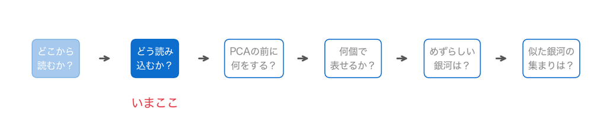

- 地図ができ、道具もそろった。では、データはどう読み込まれているか

## 2つの形式

2節 ① 2つの形式●○○○○

- `CANDELS/GDS_1000.npy`など：numpyの配列を、そのまま保存した形式（.npy）
- `GDS_RGBs/GDS_01000.png`など：ふつうの画像の形式（PNG）
- 形式ごとに、読む関数が違う

## お手本：2つの形式で読む

2節 ① 2つの形式●●○○○

```python
x = np.load('CANDELS/GDS_1000.npy', allow_pickle=True)
im = plt.imread('GDS_RGBs/GDS_01000.png')
print(x.shape, x.dtype, x.min().round(3), x.max().round(3))
print(im.shape, im.dtype, im.min(), im.max())
```

- `np.load`で .npyを、`plt.imread`でPNGを読む

## 形は同じ、中身が違う

2節 ① 2つの形式●●●○○

```
(30, 30, 3) float32 -0.015 0.185
(30, 30, 3) float32 0.0 1.0
```

- どちらも30×30×3の配列
- .npyは −0.015〜0.185、PNGは0〜1

## 測った値と、見るための絵

2節 ① 2つの形式●●●●○

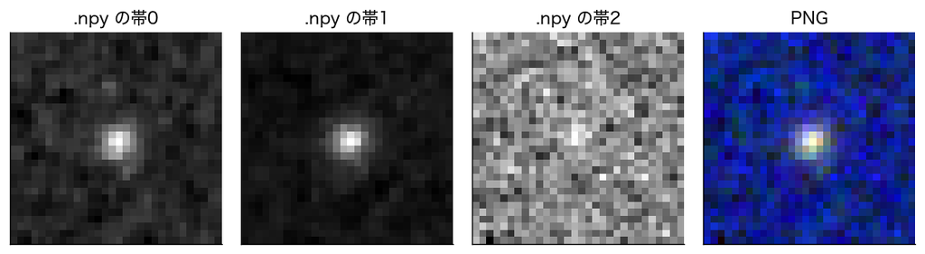

- .npyは望遠鏡が測った明るさそのもの。マイナスの値もある
- PNGは、人が見るために0〜1に直したカラー画像

## どちらを使う？

2節 ① 2つの形式●●●●●

- 解析には .npy（測った値）
- 目で見るには、PNG（カラー画像）

## たくさんのファイルを集める

2節 ② glob●○○○

- 銀河は1,222個。ファイルの名前を1つずつ書くわけにはいかない
- 名前の型に合うファイルを、まとめて集めたい

## お手本：globで集める

2節 ② glob●●○○

```python
files = glob('CANDELS/*.npy')
print(len(files))
print(files[:3])
```

- `*`の所に何が入ってもよい、という型に合うファイルの名前を、リストで返す

## 1,222個

2節 ② glob●●●○

```
1222
['CANDELS/GDS_1112.npy', 'CANDELS/GDS_1106.npy', 'CANDELS/GDS_2369.npy']
```

- 並びは、`GDS_1000`、`GDS_1001`… の順ではない

## globの順番は、変わる

2節 ② glob●●●●

- `glob`が返す順番は、計算機やファイルの置かれ方によって変わることがある
- 並びが変わると、このあとの結果の並びも変わる
- 覚えておく

## 前処理の関数のセル

2節 ③ セル5●

- 著者のセル5には、関数が5つ入っている
- `rescale`、`get_angle`、`rotation`、`normalise_all`、`get_data`（ほかに`get_catalog`）
- 長いセルだが、いまは実行するだけ

## お手本：get_data

2節 ④ get_data●○○○○○

```python
def get_data():
    L=[]
    def f(x): return re.search("[^/]+(?=.npy)",x)[0]
    fns=[x for x in map(f,glob("CANDELS/*.npy"))]
    skip=[]
    for fn in fns:
        x=np.load("CANDELS/%s.npy" % fn,allow_pickle=True)
        skip.append(any([x[:,:,i].max()==0 for i in range(0,SHP[2])]))
        L.append(x.flatten())
    a=np.row_stack(L)
    I=(a.std(axis=1)!=0) & ~(np.array(skip))
    return a[I],np.array(fns)[I]
```

- 著者のセル5の中の、`get_data`の部分

## 役割・入力・出力

2節 ④ get_data●●○○○○

- 役割：.npyのファイルをすべて読み、1つの銀河を1行にした表にする。写っていない画像は外す
- 入力：なし（`CANDELS`の中のファイル）
- 出力：表と、名前の並び

## ブロック①：名前を集める

2節 ④ get_data●●●○○○

```python
    def f(x): return re.search("[^/]+(?=.npy)",x)[0]
    fns=[x for x in map(f,glob("CANDELS/*.npy"))]
```

- `glob`で .npyのファイルを集める
- `re.search`で、`GDS_1000`のような名前の部分だけを取り出す（`re`は、文字の型で探す道具）

## ブロック②：1つずつ読む

2節 ④ get_data●●●●○○

```python
    for fn in fns:
        x=np.load("CANDELS/%s.npy" % fn,allow_pickle=True)
        skip.append(any([x[:,:,i].max()==0 for i in range(0,SHP[2])]))
        L.append(x.flatten())
```

- `np.load`で読み、`flatten()`で横一列にして、リスト`L`にためる
- 3つの帯のどれかが真っ暗（最大が0）なら、`skip`にTrueを記録

## flatten：横一列に

2節 ④ get_data●●●●●○

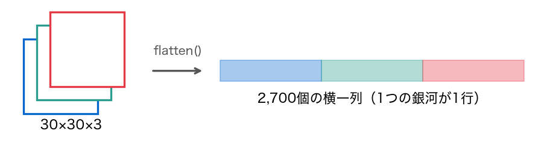

- 30×30×3＝2,700個の数を、横一列に並べる

## ブロック③：表にして、外す

2節 ④ get_data●●●●●●

```python
    a=np.row_stack(L)
    I=(a.std(axis=1)!=0) & ~(np.array(skip))
    return a[I],np.array(fns)[I]
```

- `np.row_stack(L)`：1列ずつを縦に積んで、表にする
- 明るさが一様（標準偏差が0）なものと、`skip`がTrueのものを外す
- 表と、名前の並びを返す

## 外す条件を確かめたい

2節 ⑤ 外す条件●○○○○○

- 外す条件は、2つ
- ① 3つの帯のどれかの最大が0 ② 全体の標準偏差が0
- 1つの銀河で、確かめてみる

## おさらい：[ ] の中のfor

2節 ⑤ 外す条件●●○○○○

```python
out = [i * 10 for i in range(3)]
print(out)
```

```
[0, 10, 20]
```

- `[式 for 名前 in 並び]`：1つずつ式を計算し、結果をリストに集める

## TODO②：外す条件

2節 ⑤ 外す条件●●●○○○

```python
# TODO: x の3つの帯の最大が0かどうかと、標準偏差が0でないかを表示する
# ヒント: print([x[:, :, i].max() == 0 for i in range(3)])
#         print(x.std() != 0)
...
```

- お手本で読んだ`x`（`GDS_1000`）で確かめる

## やってみよう：2節とTODO②

2節 ⑤ 外す条件●●●●○○

- 2節のお手本と、著者のセル5を実行する
- TODO②で、外す条件を確かめる

動画の人は、ここで一時停止。

## 答え合わせ：TODO②

2節 ⑤ 外す条件●●●●●○

```python
print([x[:, :, i].max() == 0 for i in range(3)])
print(x.std() != 0)
```

```
[np.False_, np.False_, np.False_]
True
```

## この銀河は、外されない

2節 ⑤ 外す条件●●●●●●

- 3つとも`False`（`np.False_`と表示される）：どの帯も真っ暗ではない
- `True`：明るさにばらつきがある
- 撮影の失敗で一部の帯が写っていない画像を、機械的に除いていた

## 並び順を、そろえたい

2節 ⑥ 並べ直す●○○

- `get_data`は、`glob`の順に読む
- 計算機によって並びが変わると、結果の並びも変わる
- 読み込んだあと、こちらで1段足して、名前の順に並べ直す

## お手本：読み込んで、並べ直す

2節 ⑥ 並べ直す●●○

```python
raw_data,indexes=get_data()             # 著者のセル9の1行目
order = np.argsort(indexes)            # ここから2行は、こちらで足した
raw_data, indexes = raw_data[order], indexes[order]
print(raw_data.shape, indexes[:3])
```

- `np.argsort`：並べ替えたときの順番（番号）を返す

## 1,222行 × 2,700列

2節 ⑥ 並べ直す●●●

```
(1222, 2700) ['GDS_1000' 'GDS_1001' 'GDS_1003']
```

- 1行が1つの銀河。名前の順に並んだ
- 1,222個を読んで1,222行が残ったので、外された銀河はなかった

# 3. 主成分分析の前に、何をしているか？

## PCAの前に、何をする？

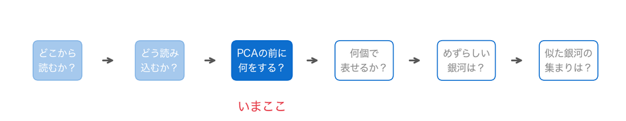

- 1,222個の銀河を表に読み込めた。主成分分析の前に、何をしているか

## normalise_all

3節 ① 2つの前処理●○○

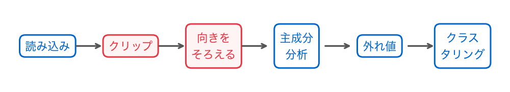

- 著者のセル9の2行目は、`normalise_all(raw_data, 0, .99)`を呼ぶ
- この関数は、2つの前処理をする

## お手本：normalise_all

3節 ① 2つの前処理●●○

```python
def normalise_all(a,lower_q,upper_q):
    a=a.copy()
    x=SHP[0]*SHP[1]
    L,U=np.quantile(a,[lower_q,upper_q])
    a=np.clip(a,L,U)
    for i in range(0,len(a)):
        d=a[i,:].reshape(SHP)
        d=rotation(d)
        a[i,:]=d.flatten()
    return a
```

## かたまりで読む

3節 ① 2つの前処理●●●

- `np.quantile`と`np.clip`：明るさを切りそろえる
- `for`の中の`rotation`：銀河を1つずつ回す
- 最初の`a=a.copy()`：渡された表の写しを作ってから変える

## 前処理①：明るさのクリップ

3節 ② クリップ●○

明るさの0%点を$L$、99%点を$U$として

$$\tilde x = \min(\max(x, L), U)$$

- $L$より小さい値は$L$に、$U$より大きい値は$U$に切りそろえる
- `np.clip(a, L, U)`がこの計算

## なぜ切りそろえる？

3節 ② クリップ●●

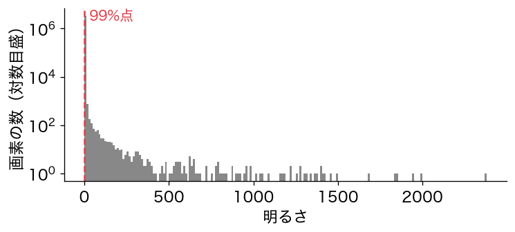

- ごく一部の、とても明るい画素がある
- その画素に、主成分分析が引っぱられないようにする

## 前処理②：向きをそろえる

3節 ③ 向き●

- 銀河ごとに、長く伸びている向きを求め、同じ向きに回す（`rotation`）
- 同じ形なのに向きだけ違う銀河を、違う形と数えないため

## 画像を並べる関数のセル

3節 ④ セル7●

- 前と後を見比べるために、著者のセル7を実行する
- `make_image`：名前に合うPNGを並べる
- `make_image_pre`：表の行を、画像にして並べる

## お手本：前と後を並べる

3節 ⑤ 前と後●○

```python
norm_data=normalise_all(raw_data,0,.99)   # 著者のセル9の2行目
make_image_pre(raw_data[:9].copy(), (3, 3), '前')   # 写しを渡す
make_image_pre(norm_data[:9].copy(), (3, 3), '後')
plt.show()
```

- 前処理をして、先頭の9個を、前と後で並べる

## 伸びた銀河が、縦に回った

3節 ⑤ 前と後●●

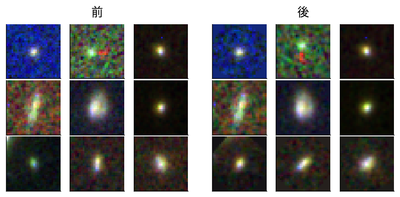

- 伸びた銀河の多くが、縦に回された。丸い銀河は、ほとんど変わらない

## なぜ.copy()を渡す？

3節 ⑥ 写し●○○

```python
        r=im[:,:,0]; r-=r.min()
        if r.max()!=0: r/=r.max()
```

- 著者のセル7の`make_image_pre`の中の2行
- `r-=r.min()`は、受け取った配列の中身を、その場で書きかえる

## 書きかわると、結果が変わる

3節 ⑥ 写し●●○

- `raw_data[:9]`をそのまま渡すと、元の表の値まで書きかわる
- あとの主成分分析の結果が変わってしまう
- `.copy()`で写しを渡せば、元の表は変わらない

## 渡したものを、書きかえないか

3節 ⑥ 写し●●●

- 他人の関数を使うときは、渡したものを書きかえないかを読んで確かめる
- 著者自身も、`normalise_all`の最初では`a=a.copy()`と写しを作っている

## 向きは、どう測る？

3節 ⑦ 角度●○○○○

```python
def get_angle(d):
    fit=PCA(n_components=2).fit(
        np.argwhere(d>=np.quantile(d,.75)))
    return np.arctan2(*fit.components_[0])
```

- 著者のセル5の`get_angle`。ここにも主成分分析が出てくる

## 1行ずつ読む

3節 ⑦ 角度●●○○○

- `np.argwhere(d >= np.quantile(d, .75))`：明るさが上位25%の画素の座標（縦・横の番号）を集める
- その座標の点の集まりに、主成分分析をかける
- `np.arctan2`で、第1主成分の向きを角度に直す

## 座標の点に、主成分分析

3節 ⑦ 角度●●●○○

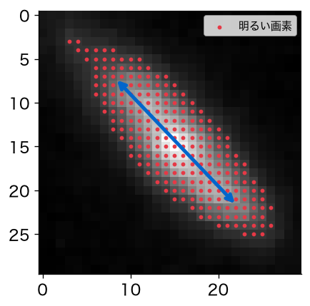

- 赤い点が明るい画素。青い矢印が第1主成分＝伸びている向き

## 散らばる向きを探す道具

3節 ⑦ 角度●●●●○

- 主成分分析は、データがいちばん散らばる向きを探す道具だった（第9回）
- ここでは、画素の座標に使って、銀河の向きを測っている

## 向きの式

3節 ⑦ 角度●●●●●

第1主成分の向きを$(v_1, v_2)$（縦・横の成分）とすると

$$\theta = \operatorname{arctan2}(v_1, v_2)$$

- 横の向きから測った角度。`np.degrees`で、度に直す

## お手本：1つの銀河の角度

3節 ⑧ 1つの銀河●○

```python
gal = np.load('CANDELS/GDS_1601.npy', allow_pickle=True)
fl = np.apply_along_axis(max, 2, gal)
print(round(np.degrees(get_angle(fl)), 1))
```

- `fl`：画素ごとに、3つの帯のいちばん明るい値を取った画像（`rotation`と同じ）

## 46.3度

3節 ⑧ 1つの銀河●●

```
46.3
```

- `GDS_1601`は、46.3度の向きに伸びていた
- `rotation`は、この角度に合わせて回し、縦（90度）にそろえる

## 全部の銀河で確かめたい

3節 ⑨ 全部の銀河●○○○○

- 1つの銀河では、ねらいどおりだった
- 1,222個すべてで、向きがそろったかを確かめる

## お手本：前と後の角度

3節 ⑨ 全部の銀河●●○○○

```python
def angle(row):                      # 1つの銀河の、伸びた向き（度）
    fl = np.apply_along_axis(max, 2, row.reshape(SHP))
    return np.degrees(get_angle(fl))

before = np.abs([angle(r) for r in raw_data])
after = np.abs([angle(r) for r in norm_data])
print(np.median(before).round(1), np.median(after).round(1))
```

## 1つの関数にまとめた

3節 ⑨ 全部の銀河●●●○○

- 1つの銀河の角度を測る3行を、関数`angle`にまとめた
- `[ ]`の中の`for`で、1,222個ぶんをリストに集める
- 角度は向きなので、絶対値（`np.abs`）で見る

## 43.8度と89.8度

3節 ⑨ 全部の銀河●●●●○

```
43.8 89.8
```

- 前処理の前は、中央値が43.8度。向きはばらばら
- 前処理の後は、89.8度。縦に集まった

## 向きが、90度に集まる

3節 ⑨ 全部の銀河●●●●●

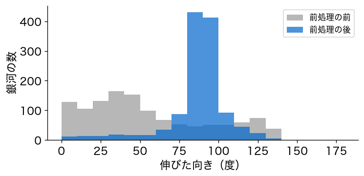

- 著者の前処理は、ねらいどおり向きをそろえていた

## やってみよう：3節

3節 10 確かめる●

- 3節の、著者のセル7と、お手本を上から実行する
- 前と後の画像、1つの銀河の角度、全部の銀河の角度を確かめる

動画の人は、ここで一時停止。

# 4. 何個の固有銀河で表せるか？

## いよいよ主張を確かめる

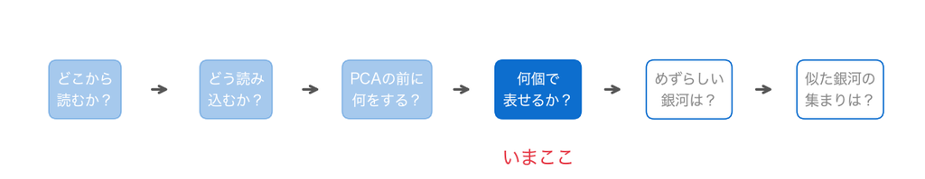

- 向きのそろった表ができた。論文の主張を確かめる

## 固有銀河

4節 ① 固有銀河●○

- 1,222個 × 2,700列の表に、主成分分析をかける
- 主成分は2,700個の数の並び。30×30×3に戻せば、画像として見られる
- これを固有銀河（eigengalaxy）と呼ぶ。第9回の固有顔と同じ考え方

## 足し算で表す

4節 ① 固有銀河●●

銀河$i$を、平均と$K$個の固有銀河$\mathbf a_k$の足し算で表す

$$\mathbf x_i \approx \bar{\mathbf x} + t_{i1}\mathbf a_1 + t_{i2}\mathbf a_2 + \cdots + t_{iK}\mathbf a_K$$

- $t_{ik}$は得点。論文の主張は「$K$は12個ほどでよい」

## お手本：主成分分析のセル

4節 ② セル11●○○○

```python
# 著者のセル11をそのまま写したもの
pca=PCA(.96).fit(norm_data)
scores=pca.transform(norm_data)
lik=pca.score_samples(norm_data)
print(pca.n_components_)
```

## PCA(.96)の意味

4節 ② セル11●●○○

- `n_components`に0〜1の数を渡すと、累積寄与率がこの割合に届くまでの数を、自動で選ぶ
- `scores`：各銀河の得点。`lik`：5節で使う

## 10個で96%

4節 ② セル11●●●○

```
10
```

- 10個の固有銀河で、1,222個の銀河の散らばりの96%を表せた
- 論文は、約1万個の銀河で約12個。近い値

## 合わせて0.96

4節 ② セル11●●●●

```python
print(pca.explained_variance_ratio_.sum().round(3))
print(pca.explained_variance_ratio_[:3].round(3))
```

```
0.96
[0.763 0.115 0.031]
```

- 10個の寄与率を足すと0.96
- 第1主成分の寄与率は0.763。2番目は0.115、3番目は0.031

## 固有銀河を描くセル

4節 ③ セル24●○

```python
# 著者のセル24をそのまま写したもの
L=[]
N=pca.n_components_
for i in range(0,N):
    comp=pca.components_[i]
    comp=comp.reshape(SHP)
    mn=comp.min();mx=comp.max()
    for j in BAND_ORDER: L.append((mn,mx,comp[:,:,j]))
fig=plt.figure(figsize=(N,3*5))
grid=ImageGrid(fig,111,nrows_ncols=(N,3),axes_pad=0)
for i,b in enumerate(BANDS): grid[i].set_title(b)
for ax, tup in zip(grid,L):
    ax.set_xticks([])
    ax.set_yticks([])
    mn,mx,im=tup
    ax.imshow(im,cmap="gray", aspect="auto",vmin=mn,vmax=mx)
#plt.savefig("components.png")
plt.show()
```

## かたまりで読む

4節 ③ セル24●●

- 1つ目の`for`：10個の主成分を30×30×3に戻し、帯ごとにリスト`L`にためる
- `ImageGrid`：画像を、10行3列の格子に並べる
- 2つ目の`for`：格子の1マスずつに、灰色の画像を描く

## 10個の固有銀河

4節 ④ 読む●○○○

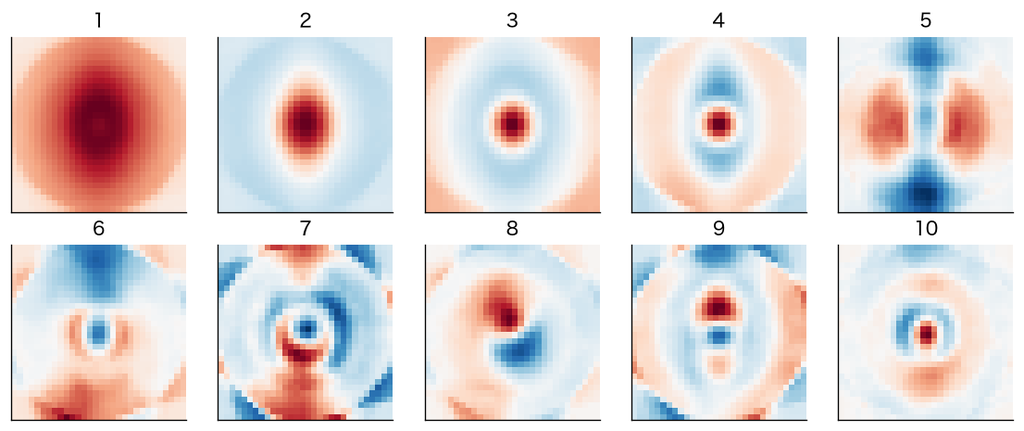

- 著者の図から、帯を1つ選んで並べ直した。赤は正、青は負

## 1つ目：全体の明るさ

4節 ④ 読む●●○○

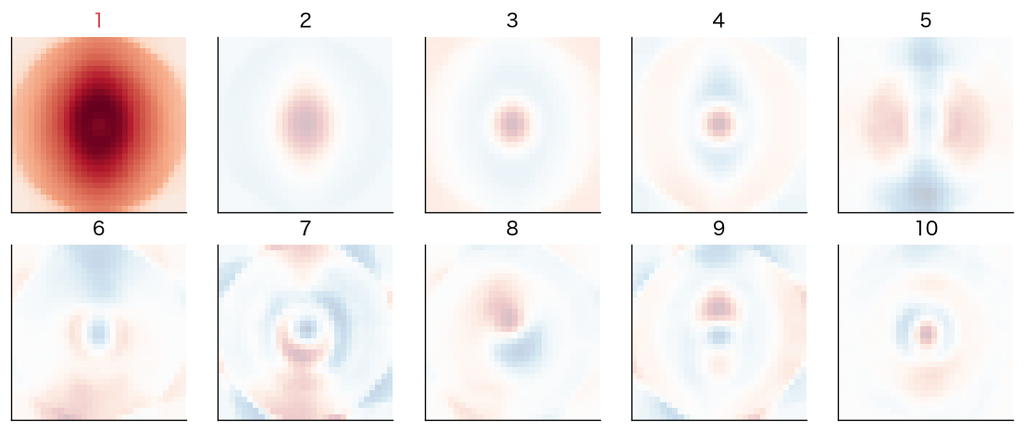

- 大きく広がった明るさ。銀河全体の明るさと大きさにあたる

## 2つ目：縦に伸びた中心

4節 ④ 読む●●●○

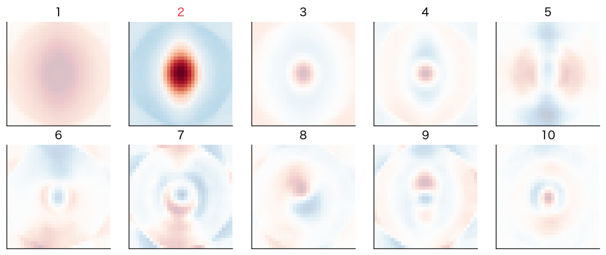

- 向きを縦にそろえたので、縦に伸びているかどうかが、2番目に大きな違いになった

## 後ろほど、細かい形

4節 ④ 読む●●●●

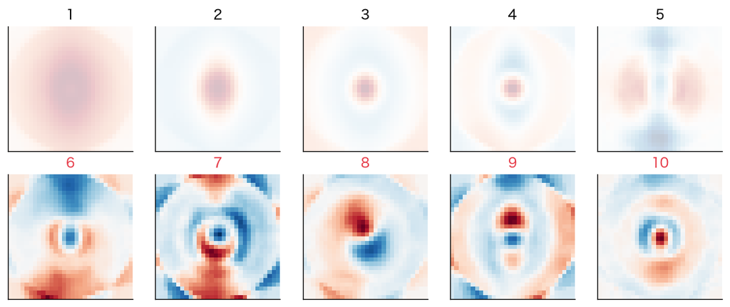

- 後ろの固有銀河ほど、上下の片寄りのような、細かい形の違いを表す

## TODO③：9割には何個？

4節 ⑤ 9割●○○○○

```python
# TODO: 累積寄与率が初めて 0.9 以上になる主成分の数を求める
# ヒント: p = PCA().fit(norm_data)
#         cum = np.cumsum(p.explained_variance_ratio_)
#         print(np.argmax(cum >= 0.9) + 1)
...
```

- 第9回と同じ書き方

## やってみよう：4節とTODO③

4節 ⑤ 9割●●○○○

- 4節の、著者のセル11・24を実行する
- TODO③で、9割を表すのに要る数を求める

動画の人は、ここで一時停止。

## 答え合わせ：TODO③

4節 ⑤ 9割●●●○○

```python
p = PCA().fit(norm_data)
cum = np.cumsum(p.explained_variance_ratio_)
print(np.argmax(cum >= 0.9) + 1)
```

```
3
```

## 3個で9割

4節 ⑤ 9割●●●●○

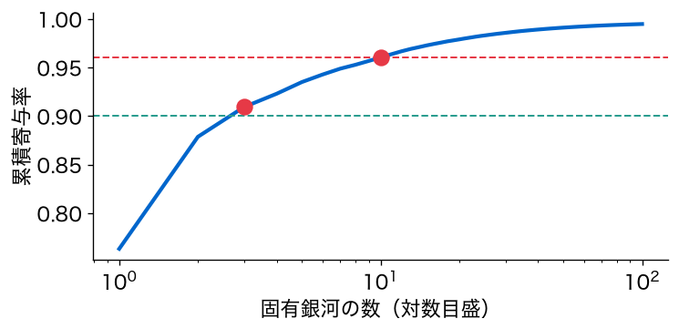

- 3個で9割、10個で96%（横は対数目盛）

## ごく少ない固有銀河で

4節 ⑤ 9割●●●●●

- 2,700個の数で表していた銀河の形の、ほとんどを、ごく少ない固有銀河で表せる
- 論文の主張どおり

## 本当に、元の形に戻る？

4節 ⑥ 組み立て直す●○○○

- 累積寄与率は、散らばりの割合
- 固有銀河の足し算で、本当に元の形に戻るかを、目で確かめる

## お手本：組み立て直す

4節 ⑥ 組み立て直す●●○○

```python
for k in [2, 10, 50]:
    p = PCA(k).fit(norm_data)
    rec = p.inverse_transform(p.transform(norm_data[:9]))
    make_image_pre(rec, (3, 3), f'{k}個')
plt.show()
```

- `inverse_transform`：得点から元の2,700列の形に戻す（第9回の再構成と同じ計算）

## 2個・10個・50個

4節 ⑥ 組み立て直す●●●○

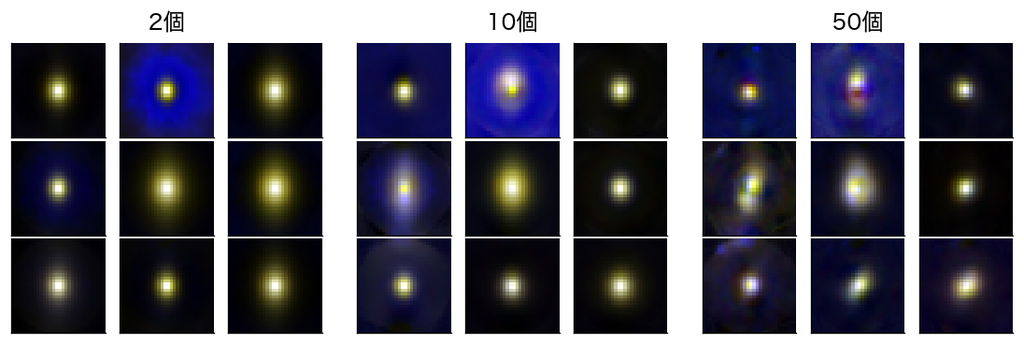

## 10個で、形が戻る

4節 ⑥ 組み立て直す●●●●

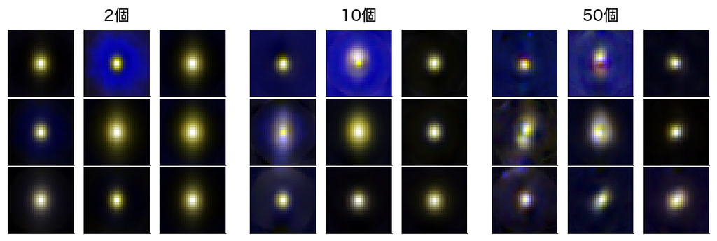

- 2個では楕円。50個では、前処理の後とほとんど同じ
- 10個で、銀河ごとの伸び方や明るさの片寄りまで戻る

# 5. めずらしい銀河は、どれか？

## うまく表せない銀河は？

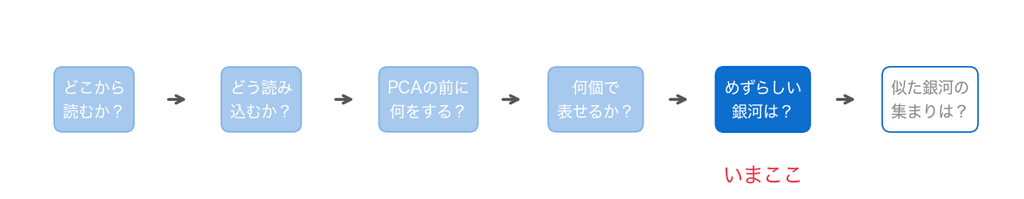

- 10個の固有銀河で、銀河の形がほぼ戻った。では、うまく表せない銀河はあるか

## ありそうさ：score_samples

5節 ① ありそうさ●○

- 著者のセル11で作った`lik`を使う
- `pca.score_samples`：各銀河が、この主成分分析のつくる「ふつうの散らばり」に、どれくらいありそうかを数にする
- 対数尤度（log-likelihood）と呼ぶ。大きいほどありそう

## 小さいほど、めずらしい

5節 ① ありそうさ●●

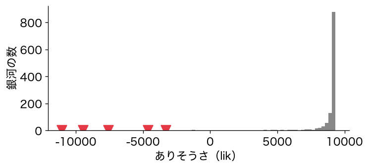

- 多くの銀河は右側に集まる。左の端（▼）の銀河が、めずらしい形

## TODO④：めずらしい5個

5節 ② めずらしい5個●○○○

```python
# TODO: lik の小さい順に、5個の名前と値を表示する
# ヒント: rare = np.argsort(lik)[:5]
#         print(indexes[rare])
#         print(lik[rare].round(0))
...
```

- `np.argsort`：小さい順に並べたときの番号

## やってみよう：5節とTODO④

5節 ② めずらしい5個●●○○

- TODO④で、いちばんめずらしい5個を探す
- そのあと、著者のセル16で、画像にして見る

動画の人は、ここで一時停止。

## 答え合わせ：TODO④

5節 ② めずらしい5個●●●○

```python
rare = np.argsort(lik)[:5]
print(indexes[rare])
print(lik[rare].round(0))
```

```
['GDS_2817' 'GDS_1332' 'GDS_1069' 'GDS_2984' 'GDS_1530']
[-11062.  -9446.  -7569.  -4639.  -3310.]
```

## いちばんめずらしい5個

5節 ② めずらしい5個●●●●

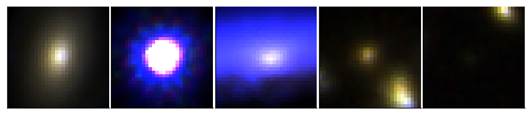

- `lik`は、大きくマイナス。どれも、ほかの銀河と形が違う

## お手本：外れ値のセル

5節 ③ セル16●○○○○

```python
# 著者のセル16をそのまま写したもの
lik_idx=indexes[np.argsort(lik)]
P=make_image(lik_idx[0:25],(5,5))
P.tight_layout()
P.savefig("most-rare.png")
P=make_image(np.flip(lik_idx)[0:25],(5,5))
P.tight_layout()
P.savefig("least-rare.png")
```

- `lik`の小さい順と大きい順に、25個ずつ並べ、ファイルに保存する

## めずらしい25個

5節 ③ セル16●●○○○

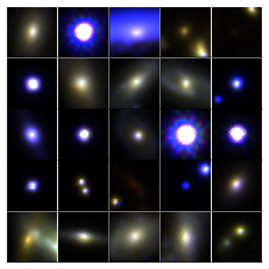

## 写りこみや、重なり

5節 ③ セル16●●●○○

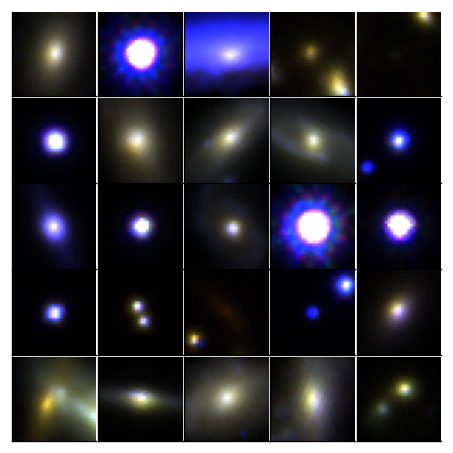

- とても明るく青い点（星が写りこんだのかもしれない）、2つ以上が1枚に写ったもの

## ありふれた25個

5節 ③ セル16●●●●○

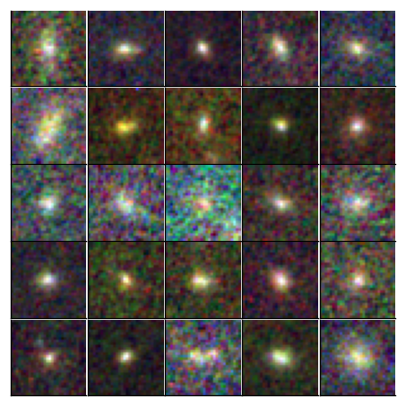

- 小さく暗い銀河ばかり

## 外れ値は、汚れも見つける

5節 ③ セル16●●●●●

- 外れ値を探すと、めずらしい銀河だけでなく、データの汚れ（写りこみ・重なり）も見つかる
- 論文の解析では、こうした画像を確かめてから使う